# Course_Proj_1 Reproducible Research

Author - David Haimes

```r
library(tidyverse)
library(ggpubr)
```

## Project Requirements

Required Steps for Analyzing Step Data Gathered from Wearable Devices  
1. Code for reading in the dataset and/or processing the data  
2. Histogram of the total number of steps taken each day  
3. Mean and median number of steps taken each day  
4. Time series plot of the average number of steps taken  
5. The 5-minute interval that, on average, contains the maximum number of steps  
6. Code to describe and show a strategy for imputing missing data  
7. Histogram of the total number of steps taken each day after missing values are imputed  
8. Panel plot comparing the average number of steps taken per 5-minute interval across weekdays and weekends  
9. All of the R code needed to reproduce the results (numbers, plots, etc.) in the report

## Assessing Total Number Steps/Day

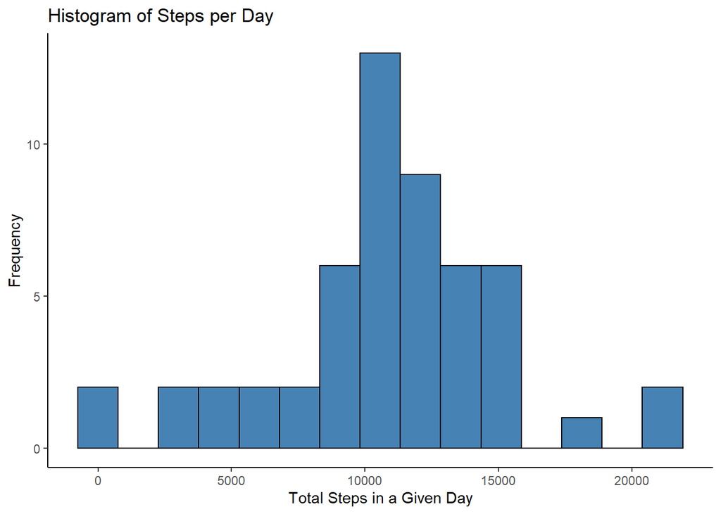

```r
#Read in dataset
#getwd()
df <- read.csv("repdata_data_activity/activity.csv", header = T)

#Transform Dataset
df <- df %>%
  mutate(Dates_Corr = as.Date(df$date, format = "%Y-%m-%d"))


# Calculate total # of steps / day
defaultW = getOption("warn") # trick to suppress warnings tripped by NAs in df
options(warn = -1)
total_steps <- df %>%
  group_by(Dates_Corr) %>%
  summarize(sum = sum(steps))
#  Histogram of total number steps taken each day
ggplot(total_steps, aes(x = sum)) +
  geom_histogram( bins = 15, col = "black", fill = "steelblue") +
  xlab("Total Steps in a Given Day") +
  ylab("Frequency") +
  ggtitle("Histogram of Steps per Day") +
  theme_classic()
```

```r
# Calculate mean and median of the total steps/day and report
step_summary <- total_steps %>%
  filter(!is.na(sum)) %>%
  summarize(mean = mean(sum), median = median(sum))
mean_steps <- format(round(as.numeric(step_summary[1]),2),nsmall=2)
median_steps <- format(round(as.numeric(step_summary[2]),2),nsmall=2)
options(warn = defaultW) # reset warnings back to normal
```

The mean of the total steps per day results is 10766.19.  
The median of the total steps per day results is 10765.00.

## Daily Activity Pattern

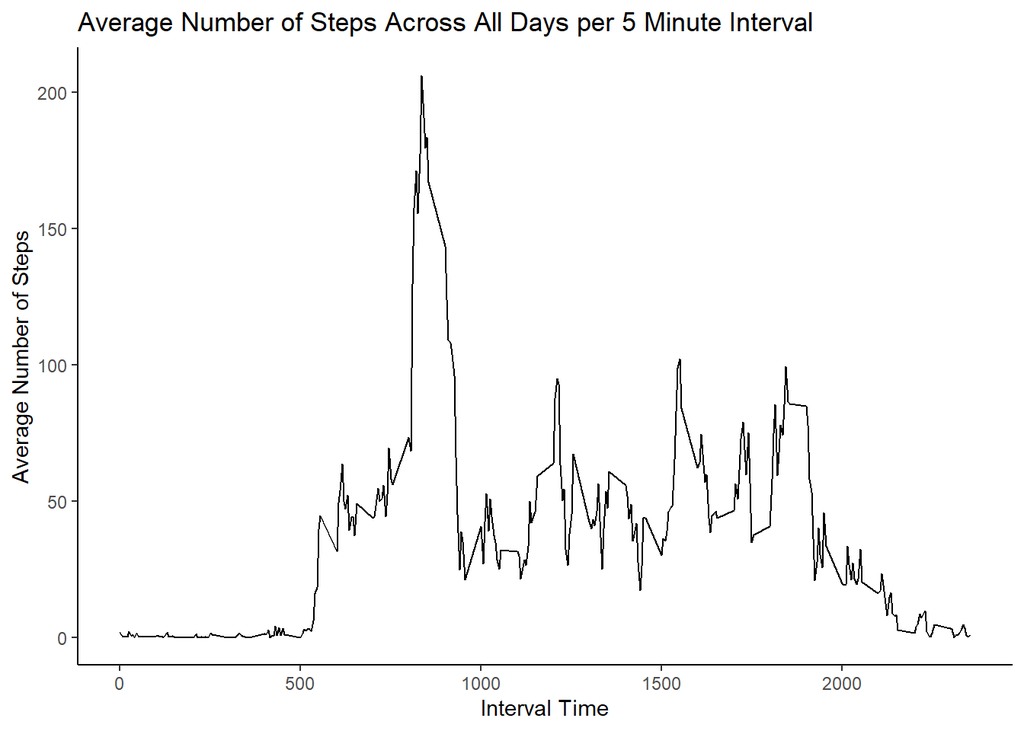

```r
#Make time series plot (type = "1") of 5m interval and avg number of steps taken across all days (y axis)

ToD_avg <- df %>%
  group_by(interval) %>%
  summarize(avg_steps = mean(steps,na.rm = T))

ToD_avg %>%
  ggplot(aes(interval, avg_steps)) +
  geom_line() +
  xlab("Interval Time") +
  ylab("Average Number of Steps") +
  ggtitle("Average Number of Steps Across All Days per 5 Minute Interval")+
  theme_classic()
```

```r
# Find Max # steps across all intervals
POI <- ToD_avg[which(ToD_avg[,2] == max(ToD_avg$avg_steps)),]
max_avgsteps <- format(round(as.numeric(POI[2]),2),nsmall=2)
interval_num <- format(round(as.numeric(POI[1]),2),nsmall=2)
```

The peak (maximum) number of steps averaged across all days is 206.17 at interval 835.00.

## Missing data Imputation

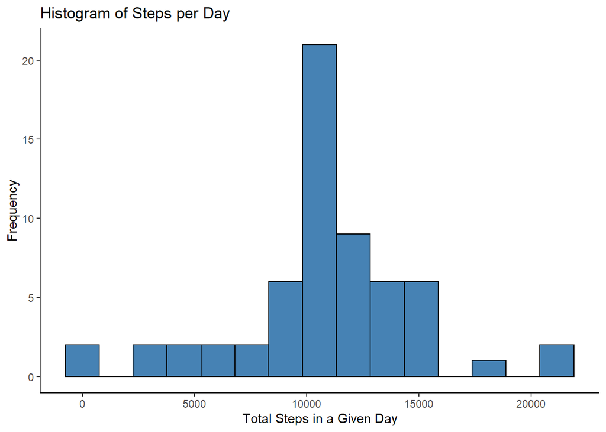

```r
# Calculate total number of NAs
total_NAs <- sum((is.na(df$steps)))

# Fill in missing values in dataset

df_replaced <- merge(df, ToD_avg, by="interval", all = T)
df_replaced <- df_replaced %>%
  mutate(steps = ifelse(is.na(df_replaced$steps),df_replaced$avg_steps,df_replaced$steps)) %>%
  select(steps,date,interval,Dates_Corr)


# Make a histogram of total num steps per day
total_steps_imputed <- df_replaced %>%
  group_by(Dates_Corr) %>%
  summarize(sum = sum(steps))
ggplot(total_steps_imputed, aes(x = sum)) +
  geom_histogram( bins = 15, col = "black", fill = "steelblue") +
  xlab("Total Steps in a Given Day") +
  ylab("Frequency") +
  ggtitle("Histogram of Steps per Day") +
  theme_classic()
```

```r
# Recalculate mean and media
step_summary_imp <- total_steps_imputed %>%
  filter(!is.na(sum)) %>%
  summarize(mean = mean(sum), median = median(sum))
mean_steps_imp <- format(round(as.numeric(step_summary_imp[1]),2),nsmall=2)
median_steps_imp <- format(round(as.numeric(step_summary_imp[2]),2),nsmall=2)
```

The above data has been transformed to replace the 2304 N/A values with the value for that interval number averaged across all days

With imputed data, the mean is 10766.19, and the median is 10766.19

# Are there differences in activity patterns between weekdays and weekends?

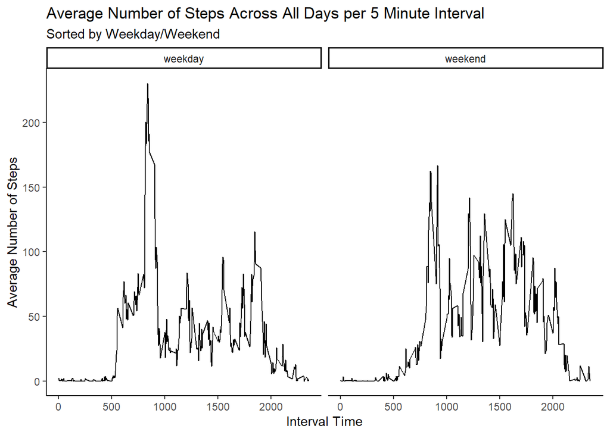

```r
# Generate new column with factors weekday or weekend
df_wk <- df_replaced %>%
  mutate(Day = ifelse(weekdays(Dates_Corr) == "Sunday" | weekdays(Dates_Corr) == "Saturday", "weekend", "weekday"))

# Make time series plot, average across weekdays or weekends
ToD_avg_Weekdays <- df_wk %>%
  group_by(Day, interval) %>%
  summarize(avg_steps = mean(steps,na.rm = T))

ToD_avg_Weekdays %>%
  ggplot(aes(interval, avg_steps)) +
  geom_line() +
  facet_wrap(~Day) +
  xlab("Interval Time") +
  ylab("Average Number of Steps") +
  labs(title = "Average Number of Steps Across All Days per 5 Minute Interval",
       subtitle = "Sorted by Weekday/Weekend")+

  theme_classic()
```